# Tutorial 9: Visualização de Dados com ggplot I

## Ajustando outras representações gráficas.

As funções scale são também muito úteis para ajustar outras representações gráficas, como `fill`, `color`, `shape`, `size`, entre outras. Alguns exemplos destas funções:

- `scale_aes_manual`: altera cores, shapes, fill para cada grupo de sua variável.
- `scale_aes_gradient`: altera escalas de cores de forma continua.
- `scale_aes_brewer`: altera palleta de cores para representação gráfica.

### scale_aes_manual

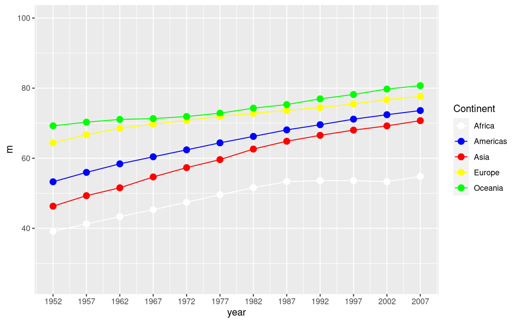

```r
ggplot(data=gap_grouped,
       aes(y=m, x=year,
           color=continent)) +
      geom_point(size=3) +
      geom_line() +
      scale_x_continuous(breaks = unique(gap_grouped$year)) +
      scale_y_continuous(limits = c(25,100)) +
      scale_color_manual(name="Continent",
                         values = c("white", "blue", "red", "yellow", "green"))
```

Usualmente, não adicionamos as cores de forma manual. O R possui paletas de cores pensadas de forma cuidadosa para representar seus gráficas. Dentre elas, minha favorita é do pacote `wesanderson`.

```r
#devtools::install_github("karthik/wesanderson")
library(wesanderson)
pal < wes_palette("Royal2")
```

[output not shown]

```r
# Novo gráfico
ggplot(data=gap_grouped,
       aes(y=m, x=year,
           color=continent)) +
      geom_point(size=3) +
      geom_line() +
      scale_x_continuous(breaks = unique(gap_grouped$year)) +
      scale_y_continuous(limits = c(25,100)) +
      scale_color_manual(name="Continent",
                         values = pal)
```

[output not shown]

### scale_aes_gradient

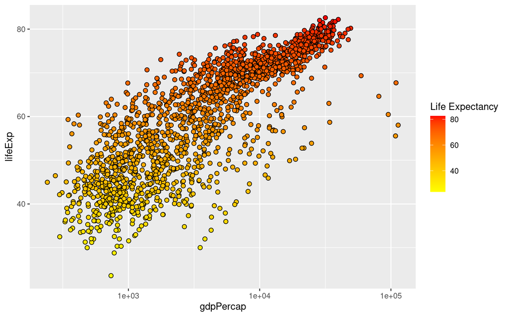

```r
ggplot(data=gapminder,
       aes(y=lifeExp, x=gdpPercap,
           fill=lifeExp)) +
      geom_point(shape=21, size=2) +
  scale_x_log10() +
  scale_fill_gradient(low="yellow", high="red",
                      name="Life Expectancy")
```

### scale_aes_brewer

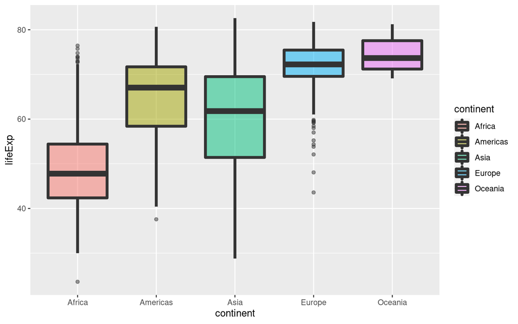

```r
# Exemplo 1
ggplot(data=gapminder, ## Etapa dos Dados
       aes(y=lifeExp, x=continent,
           fill=continent)) + # Etapa de Mapear

      # Pontos

    geom_boxplot(size=1.5,
                 alpha=.5)  # Etapa do Geom
```

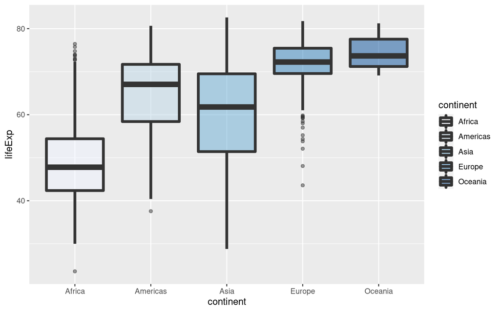

```r
# Exemplo 2
ggplot(data=gapminder, ## Etapa dos Dados
       aes(y=lifeExp, x=continent,
           fill=continent)) + # Etapa de Mapear

      # Pontos

    geom_boxplot(size=1.5,
                 alpha=.5) +  # Etapa do Geom

    scale_fill_brewer(palette = "Blues")
```

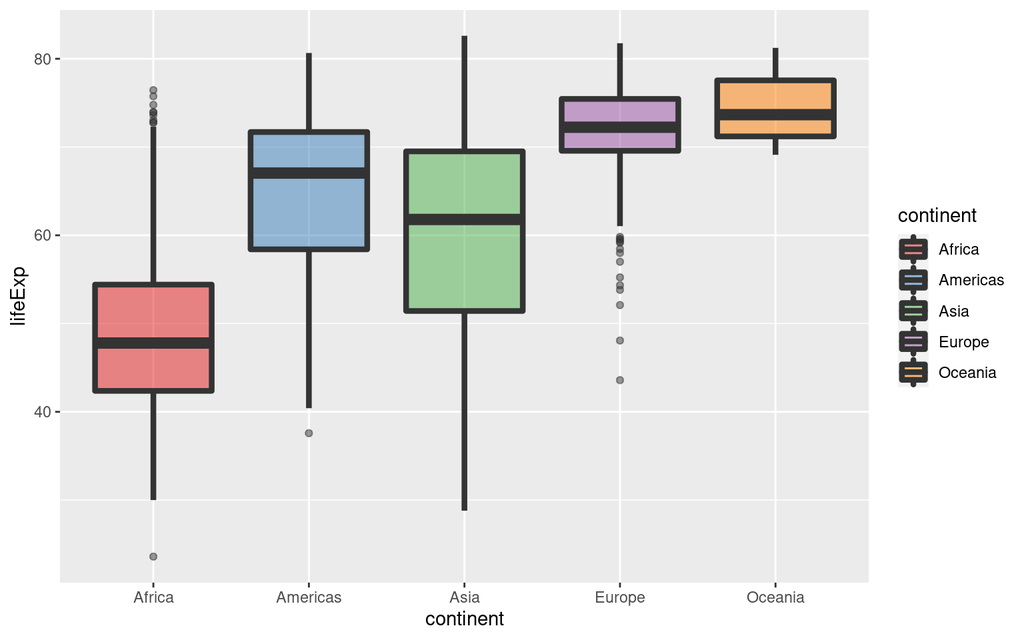

```r
# Exemplo 3
ggplot(data=gapminder, ## Etapa dos Dados
       aes(y=lifeExp, x=continent,
           fill=continent)) + # Etapa de Mapear
    geom_boxplot(size=1.5,
                 alpha=.5) +  # Etapa do Geom

    # fill

    scale_fill_brewer(palette = "Set1")
```

Para ver todas as paletas disponíveis:

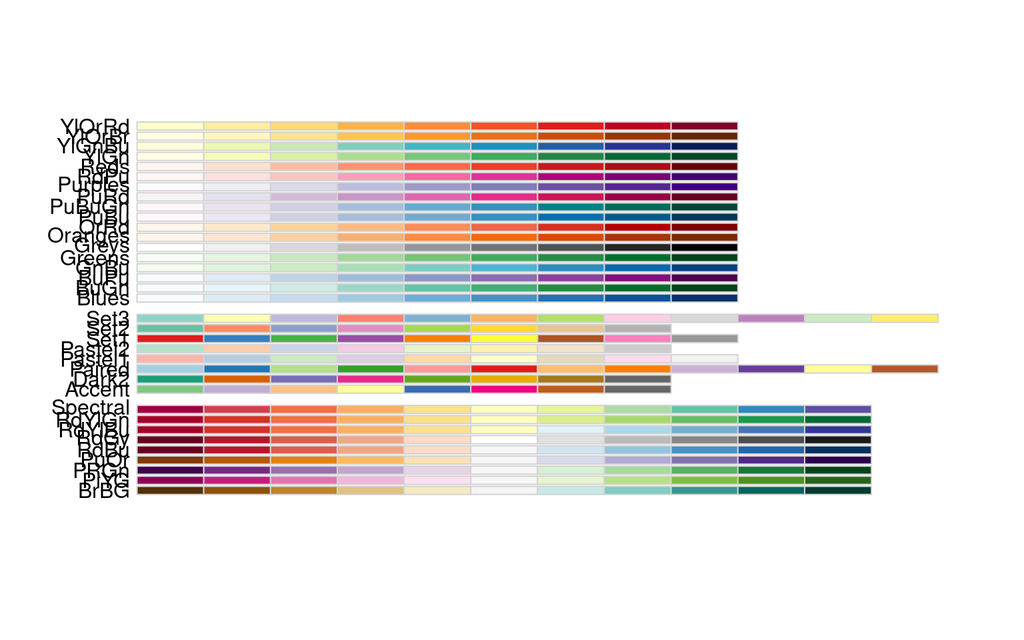

```r
#install.packages("RColorBrewer")
library(RColorBrewer)
RColorBrewer::display.brewer.all()
```

## Labels e Títulos

Ajustar os labels dos seus gráficos e títulos usando ggplot2 é super intuitivo. Como você pode imaginar, precisamos somente adicionar uma nova camada com a função `labs()`

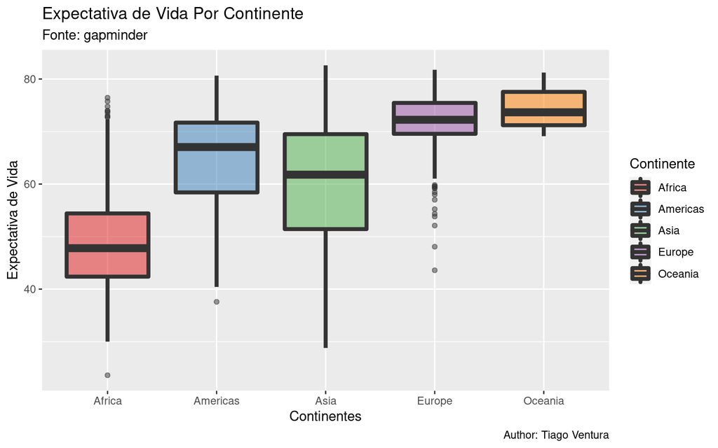

```r
ggplot(data=gapminder,  aes(y=lifeExp, x=continent,
           fill=continent)) + # Etapa de Mapear
    geom_boxplot(size=1.5, alpha=.5) +  # Etapa do Geom
    scale_fill_brewer(palette = "Set1") +

    # Nova camada

  labs(
    x = "Continentes",
    y = "Expectativa de Vida",
    fill = "Continente",
    title = "Expectativa de Vida Por Continente",
    subtitle = "Fonte: gapminder",
    caption = " Author: Tiago Ventura"
  )
```

## Facetting.

O último truque do ggplot que é muito útil quando trabalhamos com dados agrupados são as funções `facet_`.

Estas funções nos permitem dividir os gráficos em pequenas partes (sub-gráficos) a partir de determinados grupos.

Essas funções funcionam como formulas em R. O que vem depois do tilda `~` será dividido em pequenos gráficos. Vejamos alguns exemplos:

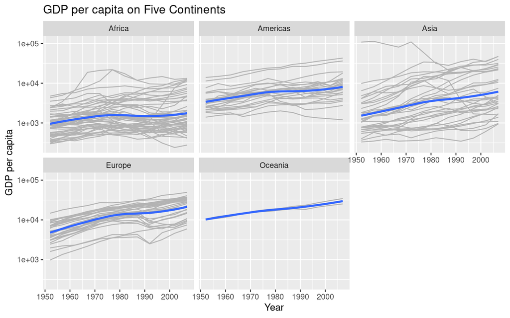

```r
# Colunas
ggplot(data = gapminder, mapping = aes(x = year, y = gdpPercap)) +
  geom_line(color="gray70", aes(group = country)) +
  geom_smooth(size = 1.1, method = "loess", se = FALSE) +
  scale_y_log10() +
  labs(x = "Year",
         y = "GDP per capita",
         title = "GDP per capita on Five Continents") +
  # facet
  facet_wrap(~ continent)
```

## Customização de forma consistente.

A maioria dos ajustes que você pode fazer em seu gráfico vão dentro da função `theme`. Ao trabalhar em um projeto, é importante que seus gráficos sejam consistentes e que você adicione essa consistência ao seu fluxo de trabalho.

Isso significa que é fundamental que seus gráficos possuam a mesma identidade para o projeto inteiro. E essa consistência é fácil de ser mantida com o ggplot2.

Uma forma de ter gráficos consistentes é desenvolver seu própria tema e aplicar este mesmo tema a todos os seus gráficos. Abaixo segue um exemplo de um tema que desenvolvi para meus gráficos.

```r
# Set up my theme  ------------------------------------------------------------
my_font <- "Palatino Linotype"
my_bkgd <- "#f5f5f2"
pal <- RColorBrewer::brewer.pal(9, "Spectral")
my_theme <- theme(text = element_text(family = my_font, color = "#22211d"),
                  rect = element_rect(fill = my_bkgd),
                  plot.background = element_rect(fill = my_bkgd, color = NA),
                  panel.background = element_rect(fill = my_bkgd, color = NA),
                  panel.border = element_rect(color="black"),
                  strip.background = element_rect(color="black", fill="gray85"),
                  legend.background = element_rect(fill = my_bkgd, color = NA),
                  legend.key = element_rect(size = 6, fill = "white", colour = NA),
                  legend.key.size = unit(1, "cm"),
                  legend.text = element_text(size = 14, family = my_font),
                  legend.title = element_text(size=14),
                  plot.title = element_text(size = 22, face = "bold", family=my_font),
                  plot.subtitle = element_text(size=16, family=my_font),
                  axis.title= element_text(size=10),

                  axis.text = element_text(size=10, family=my_font),
                  axis.title.x = element_text(hjust=1),
                  strip.text = element_text(family = my_font, color = "#22211d",
                                            size = 10, face="italic"))

my_theme  <- theme_bw() + my_theme
```

A partir daí, você precisa dizer ao seu ambiente em R para utilizar este tema como modelo:

```r
# This sets up for all your plots
theme_set(theme_bw() + my_theme)
```

Ou você pode fazer isto manualmente em cada gráfico:

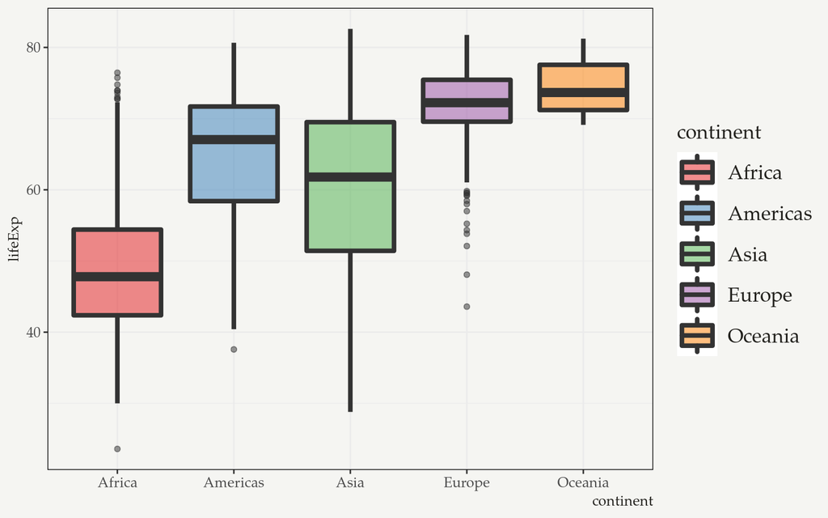

```r
graph <- ggplot(data=gapminder,
                aes(y=lifeExp, x=continent,
           fill=continent)) + # Etapa de Mapear
    geom_boxplot(size=1.5, alpha=.5) +  # Etapa do Geom
    scale_fill_brewer(palette = "Set1")

graph +  my_theme
```

Outra opção, mais recomendada para quem está iniciando em R, é usar temas pré-construídos do ggplot2 e outros pacotes.

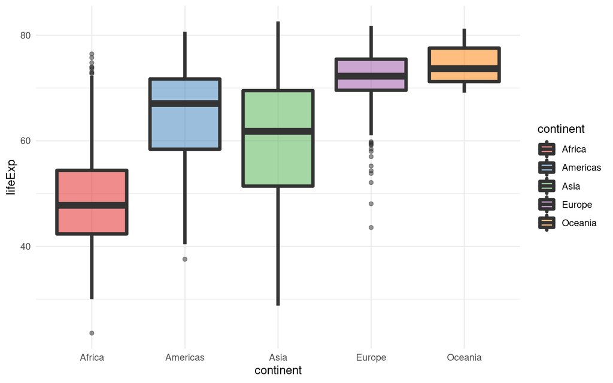

```r
#install.packages(c("ggthemes", "hbrthemes"))
library(ggthemes)
library(hrbrthemes)


graph +
  theme_minimal()
```

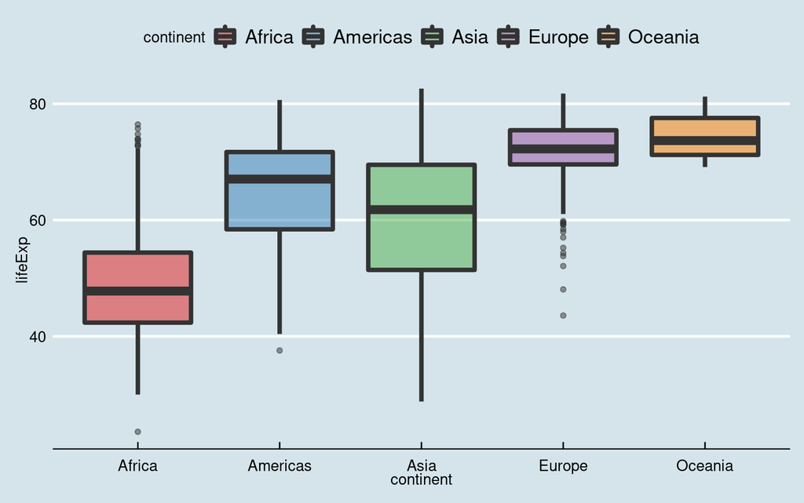

```r
graph +
  theme_economist()
```

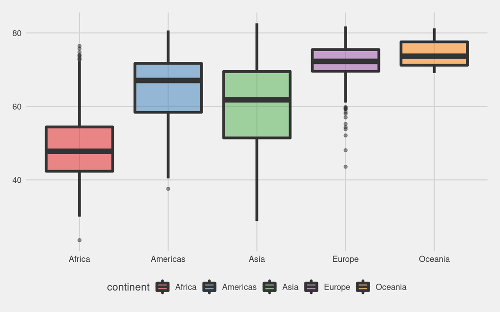

```r
graph +
  theme_fivethirtyeight()
```

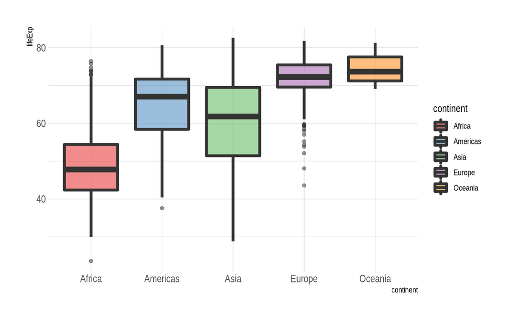

```r
graph +
  theme_ipsum()
```

## Desafio (Valendo Ponto Extra).

Valendo ponto extra para o exercício da próxima semana. Eu compartilhei no slack alguns artigos que escrevi nos últimos anos usando ggplot. O desafio de vocês é escolher um gráfico favorito dentre estes artigos, e me mandar via slack. Na próxima aula, vamos reproduzir integralmente os gráficos que vocês escolherem.

E nesta semana não teremos exercício. Podem descansar!